# NEEA Energy Analysis

Wylie Hampson

2025-02-19

Case Objective: Please prepare a case analysis in order to answer the questions below. This should include documentation of your work in this file as well as a presentation that discusses your approach, logic and recommendations to management. This case is designed to not require more than 2 hours of your time to successfully complete. We are not looking for a single right answer, but for insights into how you approach analysis and present your insights.

Situation: Washington State has an Energy Savings goal of being 70% below the 2006 Code average. NEEA’s Codes and Standards team is developing a strategy to support this goal and is seeking to understand which scenario(s) the organization should try to influence the market towards. The questions stated below are to help assess this program potential. Disclaimer: data provided within this file are fictitious

```r
knitr::opts_chunk$set(echo = TRUE)

# Load in packages
library(tidyverse)
```

```r
library(ggplot2)
```

```r
# I want to separate the data into separate tables to help with organization
base_table <- readxl::read_xlsx("data/market_data.xlsx", range = "B5:C14", sheet = "Energy Use") %>% dplyr::rename(year = Code) %>%
  janitor::clean_names()

# Add correct years to base table to replace NA values
base_table[2:4,1] <- 2006
base_table[6:9, 1] <- 2021

# Read in each table and attach them to the base table and clean them up. I'm also going to convert all tables to kBtu to compare similar units.
energy_use_electric <- readxl::read_xlsx("data/market_data.xlsx", range = "D5:J14", sheet = "Energy Use") %>%
  janitor::clean_names() %>% #clean column names to make them easier to work with
  dplyr::bind_cols(base_table) %>% # Bind the base table with the electric table.
  dplyr::select(year, base_heating_system, everything()) %>% # Reorder columns.
  dplyr::mutate(across(3:last_col(), ~ .x * 3.412)) # convert kWh to kBtu

energy_use_electric <- energy_use_electric %>%
  tidyr::pivot_wider(names_from = year, values_from = energy_use_electric %>% select(-year, -base_heating_system) %>% names(), names_sep = "_")

energy_use_gas <- readxl::read_xlsx("data/market_data.xlsx", range = "K5:M14", sheet = "Energy Use") %>%
  janitor::clean_names() %>%
  dplyr::bind_cols(base_table) %>%
  dplyr::select(year, base_heating_system, everything()) %>%
  dplyr::mutate(across(3:last_col(), ~ .x * 100))  # convert therm to kBtu

energy_use_gas <- energy_use_gas %>%
  tidyr::pivot_wider(names_from = year, values_from = energy_use_gas %>% select(-year, -base_heating_system) %>% names(), names_sep = "_")

energy_use_electric_and_gas <- readxl::read_xlsx("data/market_data.xlsx", range = "N5:T14", sheet = "Energy Use") %>%
  janitor::clean_names() %>%
  dplyr::bind_cols(base_table) %>%
  dplyr::select(year, base_heating_system, everything()) # no need to convert, already in kBtu

energy_use_electric_and_gas <- energy_use_electric_and_gas %>%
  tidyr::pivot_wider(names_from = year, values_from = energy_use_electric_and_gas %>% select(-year, -base_heating_system) %>% names(), names_sep = "_")

energy_use_electric_and_gas
```

```
## # A tibble: 5 × 15
##   base_heating_system        heating_2006 heating_2021 cooling_2006 cooling_2021
##   <chr>                             <dbl>        <dbl>        <dbl>        <dbl>
## 1 Gas Furnace                      52261.       15365.           0            0
## 2 Gas Furnance with Air Con…       53402.       15537.        1845.        1191.
## 3 Air Source Heat Pump (Ele…       17144.        8529.        1946.        1154.
## 4 Zonal Electric                   28680.        8771.           0          576.
## 5 Gas with Heat Pump Back Up          NA         8216.          NA         1143.
## # … with 10 more variables: ventilation_fans_2006 <dbl>,
## #   ventilation_fans_2021 <dbl>, lighting_2006 <dbl>, lighting_2021 <dbl>,
## #   dhw_2006 <dbl>, dhw_2021 <dbl>, appliances_2006 <dbl>,
## #   appliances_2021 <dbl>, all_2006 <dbl>, all_2021 <dbl>
```

```r
weights <- readxl::read_xlsx("data/market_data.xlsx", range = "B3:D9", sheet = "Weights") %>% dplyr::slice(-1) %>%
  dplyr::rename(weights_2006 = `2006`,
                weights_2021 = `2021`,
                base_heating_system = `HVAC System`) %>%
  dplyr::mutate(weights_2006 = as.numeric(weights_2006),
                weights_2021 = as.numeric(weights_2021))

weights
```

```
## # A tibble: 5 × 3
##   base_heating_system                weights_2006 weights_2021
##   <chr>                                     <dbl>        <dbl>
## 1 Gas Furnace                              0.545        0.0824
## 2 Gas Furnance with Air Conditioning       0.285        0.0412
## 3 Air Source Heat Pump (Electric)          0.129        0.809
## 4 Zonal Electric                           0.0404       0.0674
## 5 Gas with Heat Pump Back Up               0            0
```

Q1: Using the data provided in this file, please estimate how close the state is to achieving the stated goal.

```r
total_energy_savings_no_gas_backup_heat_pump <- energy_use_electric_and_gas %>%
  dplyr::filter(base_heating_system != "Gas with Heat Pump Back Up")

new_row <- tibble(base_heating_system = "All Systems", weights_2006 = NA, weights_2021 = NA)

weights <- bind_rows(weights, new_row)

total_energy_savings_no_gas_backup_heat_pump <- total_energy_savings_no_gas_backup_heat_pump %>%
  dplyr::select(base_heating_system, all_2006, all_2021) %>%
  dplyr::left_join(weights, by = "base_heating_system") %>%
  dplyr::mutate(weighted_use_2006 = all_2006 * weights_2006,
                weighted_use_2021 = all_2021 * weights_2021)

total_energy_savings_no_gas_backup_heat_pump <- total_energy_savings_no_gas_backup_heat_pump %>%
  dplyr::bind_rows(summarise(total_energy_savings_no_gas_backup_heat_pump,
                             base_heating_system = "All Systems",
                             across(-base_heating_system, sum))) %>%
  dplyr::mutate(energy_saving_percent = ((all_2006 - all_2021) / all_2006) * 100,
                energy_saving_percent_weighted = ((weighted_use_2006 - weighted_use_2021) / weighted_use_2006) * 100)

total_energy_savings_no_gas_backup_heat_pump
```

```
## # A tibble: 5 × 9
##   base_heating_sys… all_2006 all_2021 weights_2006 weights_2021 weighted_use_20…
##   <chr>                <dbl>    <dbl>        <dbl>        <dbl>            <dbl>
## 1 Gas Furnace         91889.   40196.       0.545        0.0824           50100.
## 2 Gas Furnance wit…   94875.   41559.       0.285        0.0412           27018.
## 3 Air Source Heat …   51852.   35619.       0.129        0.809             6700.
## 4 Zonal Electric      61443.   35100.       0.0404       0.0674            2481.
## 5 All Systems        300059.  152474.       1.00         1                86300.
## # … with 3 more variables: weighted_use_2021 <dbl>,
## #   energy_saving_percent <dbl>, energy_saving_percent_weighted <dbl>
```

Q2: Based on that analysis and trends, please identify a scenario you would recommend for the state to meet this goal. What would you present to management for consideration?

```r
calculate_total_weighted_saving_percent <- function(gas_furnace = 40196.08,
                                                    gas_furnace_w_ac = 41558.87,
                                                    heat_pump_elec = 35619.49,
                                                    zonal_elec = 35099.94,
                                                    gas_w_pump_backup = 34272.75,
                                                    gas_furnace_weight = 0.08,
                                                    gas_furnace_w_ac_weight = 0.04,
                                                    heat_pump_elec_weight = 0.81,
                                                    zonal_elec_weight = 0.07,
                                                    gas_w_pump_backup_weight = 0) {

  weight_total <- sum(gas_furnace_weight, gas_furnace_w_ac_weight, heat_pump_elec_weight, zonal_elec_weight, gas_w_pump_backup_weight)

  gas_furnace_2006 <- 91888.65
  gas_furnace_w_ac_2006 <- 94875.08
  heat_pump_elec_2006 <- 51852.46
  zonal_elec_2006 <- 61442.60
  gas_furnace_weight_2006 <- 0.55
  gas_furnace_w_ac_weight_2006 <- 0.28
  heat_pump_elec_weight_2006 <- 0.13
  zonal_elec_weight_2006 <- 0.04

  total_energy_use_weighted <- sum((gas_furnace * gas_furnace_weight),
                                   (gas_furnace_w_ac * gas_furnace_w_ac_weight),
                                   (heat_pump_elec * heat_pump_elec_weight),
                                   (zonal_elec * zonal_elec_weight),
                                   (gas_w_pump_backup * gas_w_pump_backup_weight))

  total_energy_use_weighted_2006 <- sum((gas_furnace_2006 * gas_furnace_weight_2006),
                                        (gas_furnace_w_ac_2006 * gas_furnace_w_ac_weight_2006),
                                        (heat_pump_elec_2006 * heat_pump_elec_weight_2006),
                                        (zonal_elec_2006 * zonal_elec_weight_2006))

  weighted_saving_percent <- ((total_energy_use_weighted_2006 - total_energy_use_weighted) / total_energy_use_weighted_2006) * 100

  return(weighted_saving_percent)

}

paste0("Washington State's energy savings percentage since the 2006 codes is ", calculate_total_weighted_saving_percent(), ".")
```

```
## [1] "Washington State's energy savings percentage since the 2006 codes is 58.0696895116602."
```

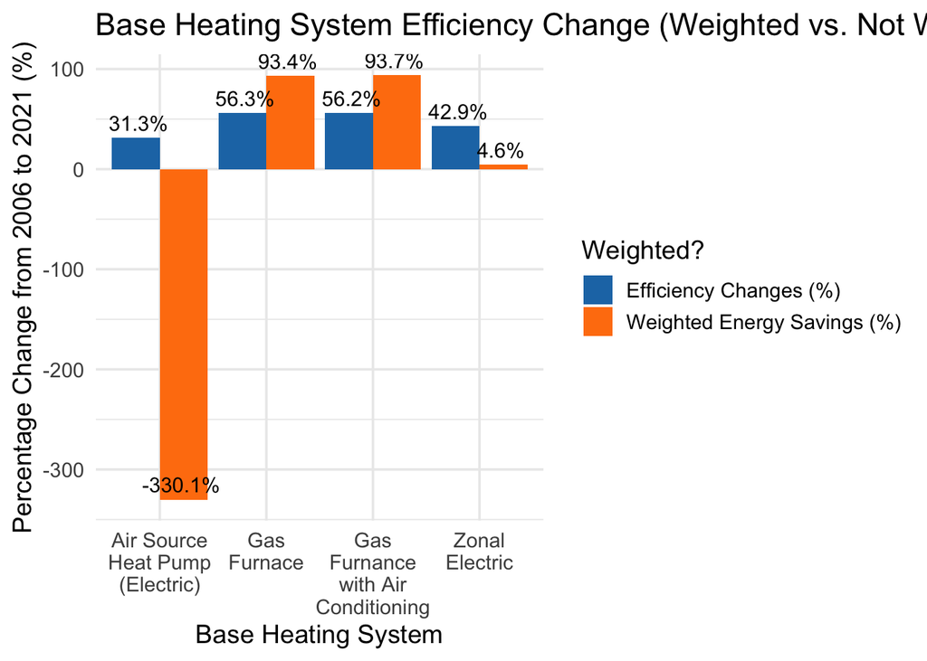

```r
plot_data <- total_energy_savings_no_gas_backup_heat_pump %>%
  dplyr::select(base_heating_system, energy_saving_percent, energy_saving_percent_weighted) %>%
  dplyr::filter(base_heating_system != "All Systems") %>%
  tidyr::pivot_longer(cols = c(energy_saving_percent, energy_saving_percent_weighted),
                      names_to = "Weighted?",
                      values_to = "percentage") %>%
  dplyr::mutate(base_heating_system = dplyr::recode(base_heating_system, "Energy Saving Percent" = "percent", "Energy Saving Percent (Weighted)" = "percent_weighted"))

plot_data$base_heating_system <- str_wrap(plot_data$base_heating_system, width = 10)

energy_savings_plot <- ggplot2::ggplot(plot_data, aes(x = base_heating_system, y = percentage, fill = `Weighted?`)) +
  ggplot2::geom_bar(stat = "identity", position = "dodge") +
  geom_text(aes(label = paste0(round(percentage, 1), "%")),
            position = position_dodge(width = 0.8),
            vjust = -0.5, size = 4) +
  labs(title = "Base Heating System Efficiency Change (Weighted vs. Not Weighted)",
       y = "Percentage Change from 2006 to 2021 (%)",
       x = "Base Heating System") +
  scale_fill_manual(values = c("#1f77b4", "#ff7f0e"),
                    labels = c("Efficiency Changes (%)", "Weighted Energy Savings (%)")) +
  theme_minimal(base_size = 14)

energy_savings_plot
```

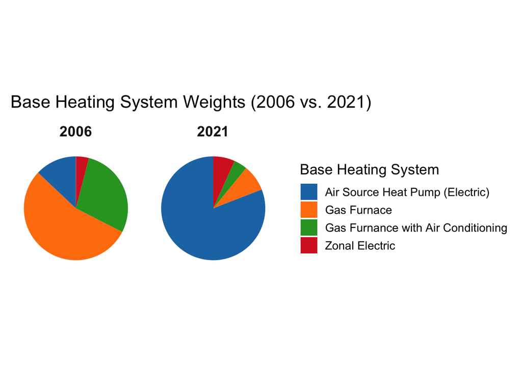

```r
plot_data_pie <- weights %>%
  dplyr::filter(base_heating_system %in% c("Gas Furnace",
                                           "Gas Furnance with Air Conditioning",
                                           "Air Source Heat Pump (Electric)",
                                           "Zonal Electric")) %>%
  pivot_longer(cols = c(weights_2006, weights_2021),
               names_to = "Year",
               values_to = "Percentage") %>%
  mutate(base_heating_system = recode(base_heating_system,
                        "Weights 2006" = "weights_2006",
                        "Weights 2021" = "weights_2021"),
         Year = ifelse(Year == "weights_2006", 2006, 2021))

weights_pie_charts <- ggplot(plot_data_pie, aes(x = "", y = Percentage, fill = base_heating_system)) +
  geom_bar(stat = "identity", width = 1) +  # Create stacked bar for pie chart
  coord_polar(theta = "y") +  # Convert to pie chart
  facet_wrap(~ Year) +  # Side-by-side pies
  labs(title = "Base Heating System Weights (2006 vs. 2021)", x = NULL, y = NULL,
       fill = "Base Heating System") +
  scale_fill_manual(values = c("#1f77b4", "#ff7f0e", "#2ca02c", "#d62728")) +  # Custom colors
  theme_minimal(base_size = 14) +
  theme(axis.text = element_blank(),  # Hide axis text
        axis.ticks = element_blank(),  # Hide axis ticks
        panel.grid = element_blank(),  # Remove grid
        strip.text = element_text(size = 14, face = "bold"))  # Style facet labels

weights_pie_charts
```

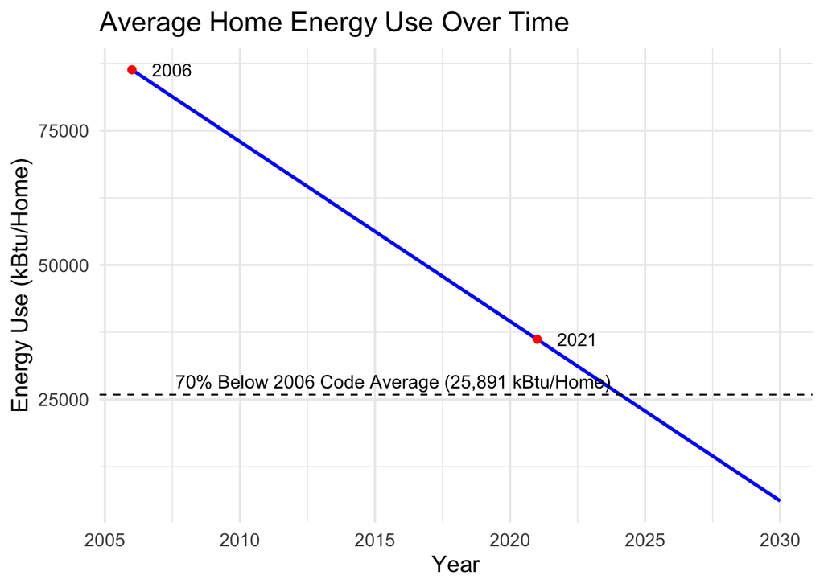

```r
avg_energy_use_rate_data <- data.frame(
  year = c(2006, 2021),
  avg_energy_use = c(86302.43, 36186.43)
)

years <- seq(2006, 2021, by = 1)  # Sequence from 2006 to 2021
avg_energy_use <- seq(86302.43, 36186.43, length.out = length(years))

line_data_2006_2021 <- data.frame(year = years, avg_energy_use = avg_energy_use)

slope <- (36186.43 - 86302.43) / (2021 - 2006)  # Calculate the slope
intercept <- 86302.43 - slope * 2006  # Calculate the intercept

years_2022_2030 <- 2022:2030
avg_energy_use_2022_2030 <- slope * years_2022_2030 + intercept

line_data_2022_2030 <- data.frame(year = years_2022_2030, avg_energy_use = avg_energy_use_2022_2030)

# Combine both data frames (2006-2021 and 2022-2030)
line_data <- rbind(line_data_2006_2021, line_data_2022_2030)

# Find the year where Energy_Use is 25890.73
target_value <- 25890.73
intersect_year <- line_data %>%
  filter(avg_energy_use <= target_value) %>%
  slice(which.min(abs(avg_energy_use - target_value))) %>%
  pull(year)


rate_plot <- ggplot(line_data, aes(x = year, y = avg_energy_use)) +
  geom_line(color = "blue", size = 1) +  # Line through both points
  geom_point(data = avg_energy_use_rate_data, aes(x = year, y = avg_energy_use), color = "red", size = 2) +  # Points for 2006 and 2021
  geom_text(data = avg_energy_use_rate_data, aes(label = c("2006", "2021")), hjust = -0.5) +
  geom_hline(yintercept = 25890.73, linetype = "dashed", color = "black") +  # Dotted vertical line
  annotate("text", x = 2006, y = 25890.73, label = "70% Below 2006 Code Average (25,891 kBtu/Home)",
           color = "black", size = 4, hjust = -0.1, vjust = -0.5) +
  labs(title = "Average Home Energy Use Over Time",
       x = "Year", y = "Energy Use (kBtu/Home)") +
  theme_minimal(base_size = 14)

rate_plot
```

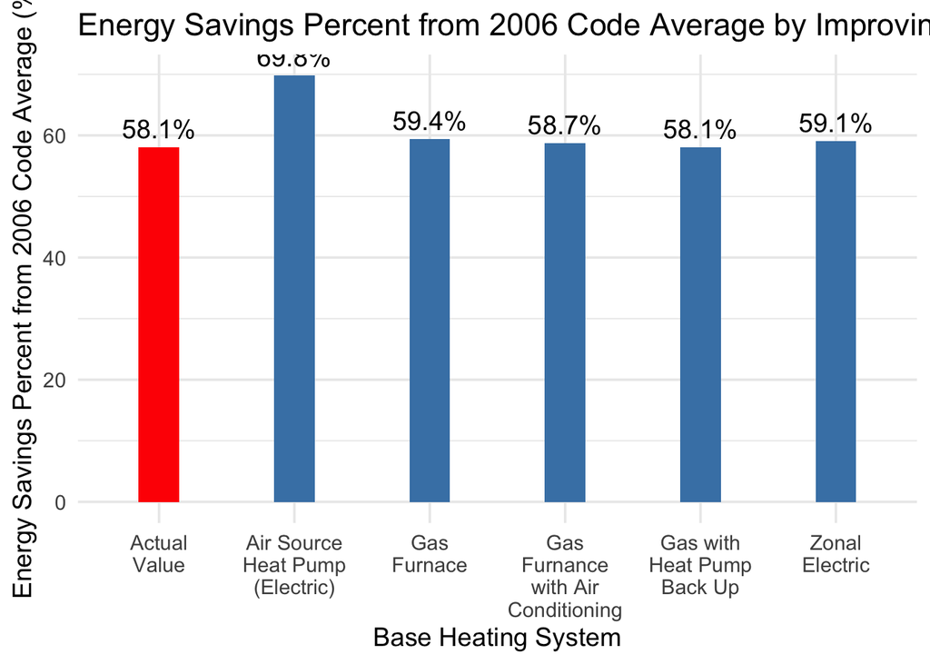

```r
adjusted_avg_energy_use_data <- data.frame(
  base_heating_system = c("Actual Value",
                          "Gas Furnace",
                          "Gas Furnance with Air Conditioning",
                          "Air Source Heat Pump (Electric)",
                          "Zonal Electric",
                          "Gas with Heat Pump Back Up"),
  energy_savings_percent = c(calculate_total_weighted_saving_percent(),
                             calculate_total_weighted_saving_percent(gas_furnace = (40196.08 * 0.65)),
                             calculate_total_weighted_saving_percent(gas_furnace_w_ac = (41558.87 * 0.65)),
                             calculate_total_weighted_saving_percent(heat_pump_elec = (35619.49 * 0.65)),
                             calculate_total_weighted_saving_percent(zonal_elec = (35099.94 * 0.65)),
                             calculate_total_weighted_saving_percent(gas_w_pump_backup = (34272.75 * 0.65)))
)

adjusted_avg_energy_use_data$color <- ifelse(adjusted_avg_energy_use_data$base_heating_system == "Actual Value", "Highlighted", "Default")

adjusted_avg_energy_use_data$base_heating_system <- factor(adjusted_avg_energy_use_data$base_heating_system,
                                                           levels = c("Actual Value",
                                                                      "Gas Furnace",
                                                                      "Gas Furnance with Air Conditioning",
                                                                      "Air Source Heat Pump (Electric)",
                                                                      "Zonal Electric",
                                                                      "Gas with Heat Pump Back Up"))

adjusted_avg_energy_use_data$base_heating_system <- str_wrap(adjusted_avg_energy_use_data$base_heating_system, width = 10)

system_impact_plot <- ggplot2::ggplot(adjusted_avg_energy_use_data, aes(x = base_heating_system, y = energy_savings_percent, fill = color)) +
  ggplot2::geom_bar(stat = "identity", position = "dodge", width = 0.3) +
  geom_text(aes(label = paste0(round(energy_savings_percent, 1), "%")),
            position = position_dodge(width = 0.8),
            vjust = -0.5, size = 5) +
  labs(title = "Energy Savings Percent from 2006 Code Average by Improving Each System by 35% Efficiency",
       y = "Energy Savings Percent from 2006 Code Average (%)",
       x = "Base Heating System") +
  scale_fill_manual(values = c("Default" = "steelblue", "Highlighted" = "red")) +
  theme_minimal(base_size = 14) +
  theme(legend.position = "none")

system_impact_plot
```